# HiSeq Supragingival Plaque Biogeography - Script 1, decontamination

Diana Proctor

December 16, 2017

Nature Communications Supplementary Data File 1 -

This is the FIRST script used to generate the main figures for the the manuscript by Proctor et al. titled “A spatial gradient of bacterial diversity in the human oral cavity shaped by salivary flow”

This script and associated data are provided via (c) by Diana M Proctor, Julia A. Fukuyama, Susan P. Holmes, David A. Relman. These data and the associated script are licensed under the Creative Commons Attribution-ShareAlike 4.0 International License (CC-BY-CA).

Given attribution, you are free to: 1) Share, copy and redistribute the material in any medium or format 2) Adapt, remix, transform, and build upon the material for any purpose, even commercially.

To see the full license associated with attribution of this work, see the CC-By-CA license, see http://creativecommons.org/licenses/by-sa/4.0/.

The local filename is: Proctor_Contaminants_v5.0.Rmd.

### Create data subsets by getting rid of the data that won’t be analyzed. This study pertains to supragingival plaque and associated controls, not studies of subgingival plaque, saliva, OM, or those studies belonging to Elies or Fiona.

```r
library("phyloseq");library("ggplot2");library(gridExtra);library(reshape2);library(doBy);library(dada2)
setwd("~/Desktop/Proctor_NatureComm/")
load("~/Desktop/Proctor_NatureComm/Hyposalivation15_phys_v1.0.Rdata") #this is hypo15 from dada2; v2 corrected map file


#Get rid of Elies, Fiona and the QC samples as well as the subgingival/om ones
keep = c("Amplification", "Clinic", "Computational", "Extraction", "Home")

unfiltered <- subset_samples(hypo15_subset, Protocol %in% keep)
unfiltered <- subset_samples(unfiltered, Aim !="QC") #get rid of the QC project samples
unfiltered <- subset_samples(unfiltered, Habitat_Class !="Sub") #delete subgingival
unfiltered <- subset_samples(unfiltered, Habitat_Class !="Saliva") #delete saliva
unfiltered <- subset_samples(unfiltered, Habitat_Class != "OM") #delete OM
unfiltered <- subset_samples(unfiltered, Habitat_Class !="Unknown") #delete unlabeled sample
unfiltered <- subset_samples(unfiltered, PoolName !="SA1_Hypo0001") #all OM samples
unfiltered <- prune_taxa(taxa_sums(unfiltered) >0, unfiltered)
unfiltered <- prune_samples(sample_sums(unfiltered) > 0, unfiltered)
unfiltered #28603 taxa, 7446 samples
```

```
## phyloseq-class experiment-level object
## otu_table()   OTU Table:         [ 28603 taxa and 7446 samples ]
## sample_data() Sample Data:       [ 7446 samples by 29 sample variables ]
## tax_table()   Taxonomy Table:    [ 28603 taxa by 6 taxonomic ranks ]
```

```r
controls = c("Computational", "Instrument", "Reagent")
sample_data(unfiltered)$Controls=ifelse(sample_data(unfiltered)$Habitat_Class %in% controls, "Control", "Sample")
```

# Center on the controls in order to identify taxa that should be removed; if a taxon has a negative value after centering it’s more abundant in the control than it is in the sample and should be removed.

```r
runs <- levels(sample_data(unfiltered)$PoolName)
holder <-vector('list',length(runs))

for(i in 1:length(runs)){
        Filt1 = subset_samples(unfiltered, PoolName==runs[[i]])
        #create a technical dataset & calculate technical taxa means
        technical <- subset_samples(Filt1, Aim =="Technical")
        tech.means = colMeans(otu_table(technical))
        #create a sample dataest & center on technical taxa means
        samples <- subset_samples(Filt1, Aim != "Technical")
        otus = otu_table(samples)
        centered= scale(otus, center = tech.means, scale = FALSE)
        otu_table(samples) = otu_table(centered, taxa_are_rows = FALSE)
        holder[[i]] <- samples
        }
centered = merge_phyloseq(holder[[1]], holder[[2]], holder[[3]], holder[[4]], holder[[5]], holder[[6]], holder[[7]], holder[[8]], holder[[9]], holder[[10]], holder[[11]], holder[[12]], holder[[13]],  holder[[14]])
centered #28603 taxa and 7005 samples
```

```
## phyloseq-class experiment-level object
## otu_table()   OTU Table:         [ 28603 taxa and 7005 samples ]
## sample_data() Sample Data:       [ 7005 samples by 30 sample variables ]
## tax_table()   Taxonomy Table:    [ 28603 taxa by 6 taxonomic ranks ]
```

```r
#subset on taxa that are present > 0
G0 = prune_taxa(taxa_sums(centered) > 0, centered)
G0 = prune_samples(sample_sums(G0) > 0, G0)
G0 #23116 taxa and 6927 samples
```

```
## phyloseq-class experiment-level object
## otu_table()   OTU Table:         [ 23116 taxa and 6927 samples ]
## sample_data() Sample Data:       [ 6927 samples by 30 sample variables ]
## tax_table()   Taxonomy Table:    [ 23116 taxa by 6 taxonomic ranks ]
```

```r
#subset on taxa that are present < 0
L0 = prune_taxa(taxa_sums(centered) < 0, centered)
L0 = prune_samples(sample_sums(L0) > 0, L0)
L0 #5487 taxa and 243 samples
```

```
## phyloseq-class experiment-level object
## otu_table()   OTU Table:         [ 5487 taxa and 243 samples ]
## sample_data() Sample Data:       [ 243 samples by 30 sample variables ]
## tax_table()   Taxonomy Table:    [ 5487 taxa by 6 taxonomic ranks ]
```

```r
rm(hypo15_subset)
```

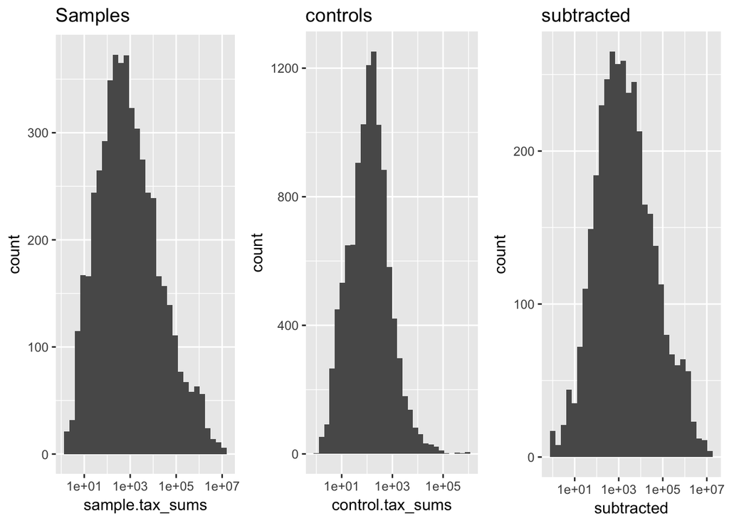

```r
library("phyloseq");library("ggplot2");library(gridExtra);library(reshape2);library(doBy)
runs <- levels(sample_data(unfiltered)$PoolName)
df.holder <- vector('list', length(runs))

for(i in 1:length(runs)){
        Filt1 = subset_samples(unfiltered, PoolName==runs[[i]])
        #create  a technical dataset &  calculate technical taxa means
        technical <- subset_samples(Filt1, Aim =="Technical") #3985 taxa; 461 samples
        technical <- prune_taxa(taxa_sums(technical) > 0, technical)
        technical <- prune_samples(sample_sums(technical) > 0, technical)
        #create a sample dataest & center on technical taxa means
        samples <- subset_samples(Filt1, Aim != "Technical") #7953 taxa are present
        samples <- prune_taxa(taxa_sums(samples) > 0, samples)
        samples <- prune_samples(sample_sums(samples) > 0, samples)

#### Plot k (prevalence) over A (abundance)

tech <- data.frame(taxa_sums(technical), rownames(tax_table(technical)), tax_table(technical), t(otu_table(technical)))
        colnames(tech)[1:2] <- c("taxa_sums", "sequences")
        #rank order
        tech <- tech[order(tech$taxa_sums, decreasing=TRUE),]
        tech$rank <- 1:ntaxa(technical)
        tech.dfm <- melt(tech, id.var=c("sequences", "rank",
        colnames(tax_table(technical))))
        tech.dfm$binary <- ifelse(tech.dfm$value > 0, "1", "0")
        tech.dfm$binary <- as.numeric(as.character(tech.dfm$binary))

samp <- data.frame(taxa_sums(samples), rownames(tax_table(samples)), tax_table(samples), t(otu_table(samples)))
        colnames(samp)[1:2] <- c("taxa_sums", "sequences")
        #rank order
        samp <- samp[order(samp$taxa_sums, decreasing=TRUE),]
        samp$rank <- 1:ntaxa(samples)
        samp.dfm <- melt(samp, id.var=c("sequences", "rank",
        colnames(tax_table(samples))))
        samp.dfm$binary <- ifelse(samp.dfm$value > 0, "1", "0")
        samp.dfm$binary <- as.numeric(as.character(samp.dfm$binary))

#compute prevalence
tech.dfm2 <- summaryBy(binary~sequences, data=tech.dfm, id=c("rank", "Phylum", "value"), FUN=sum)
        dim(tech.dfm2) #should be equal to ntaxa(technical)
        tech.dfm2$prevalence <- 1+(100*(tech.dfm2$binary.sum/nsamples(technical)))
        rownames(tech.dfm2) <- tech.dfm2$sequences

samp.dfm2 <- summaryBy(binary~sequences, data=samp.dfm, id=c("rank", "Phylum", "value"), FUN=sum)
        dim(samp.dfm2) #should be equal to ntaxa(samples)
        samp.dfm2$prevalence <- 1+(100*(samp.dfm2$binary.sum/nsamples(samples)))
        rownames(samp.dfm2) <- samp.dfm2$sequences

#force the ordering of the two data frame to be the same
samp.dfm3 = samp.dfm2[rownames(tech.dfm2),]

df = data.frame(samp.dfm3$binary.sum, tech.dfm2$binary.sum, samp.dfm3$value, tech.dfm2$value, samp.dfm3$rank, tech.dfm2$rank,  samp.dfm3$Phylum, samp.dfm3$sequences)
df$PoolName <- runs[[i]]

colnames(df) <- c("sample.prevalence", "control.prevalence", "sample.tax_sums", "control.tax_sums","sample.rank", "control.rank", "Phylum", "Sequence")

df.holder[[i]] <- df
}

cont.df <- do.call("rbind", df.holder)
colnames(cont.df)[9] <- "run"
cont.df$subtracted <- cont.df$sample.tax_sums-cont.df$control.tax_sums
cont.df$number <- 1:nrow(cont.df)
p1=ggplot(cont.df, aes(sample.tax_sums)) + geom_histogram()+ scale_x_log10() + ggtitle("Samples")
p2=ggplot(cont.df, aes(control.tax_sums)) + geom_histogram()+ scale_x_log10() + ggtitle("controls")
p3 = ggplot(cont.df, aes(subtracted)) + geom_histogram()+ scale_x_log10() + ggtitle("subtracted")
grid.arrange(p1, p2, p3, ncol=3)
```

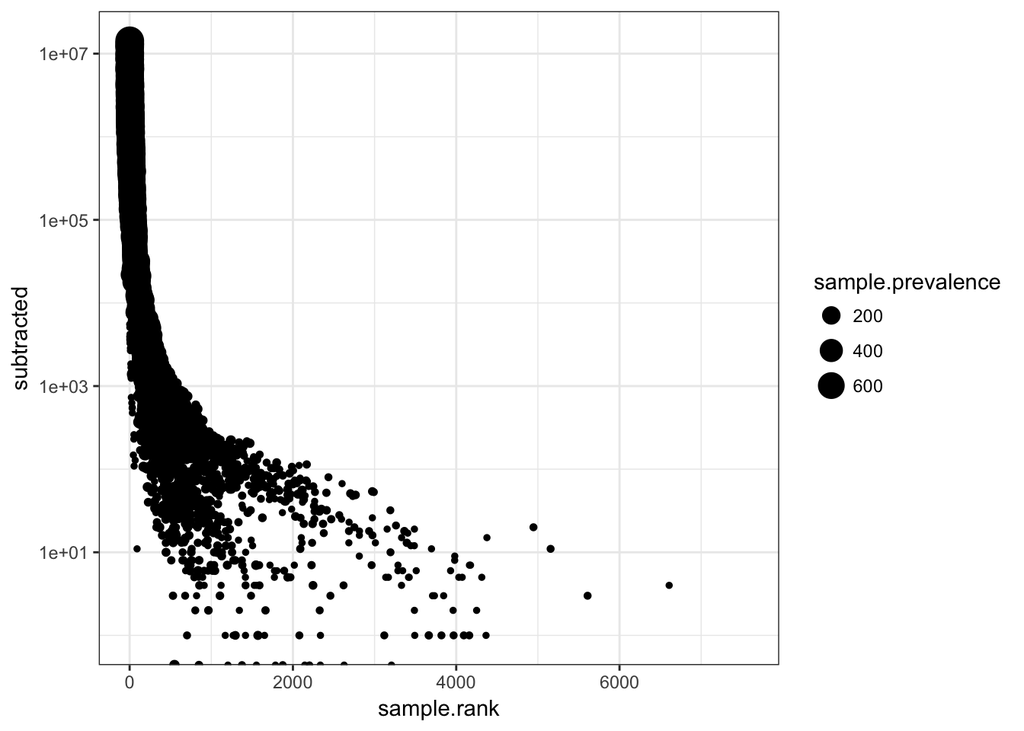

```r
px=ggplot(cont.df, aes(sample.rank, subtracted, size=sample.prevalence)) + geom_point()+ scale_y_log10() + theme_bw()
px
```

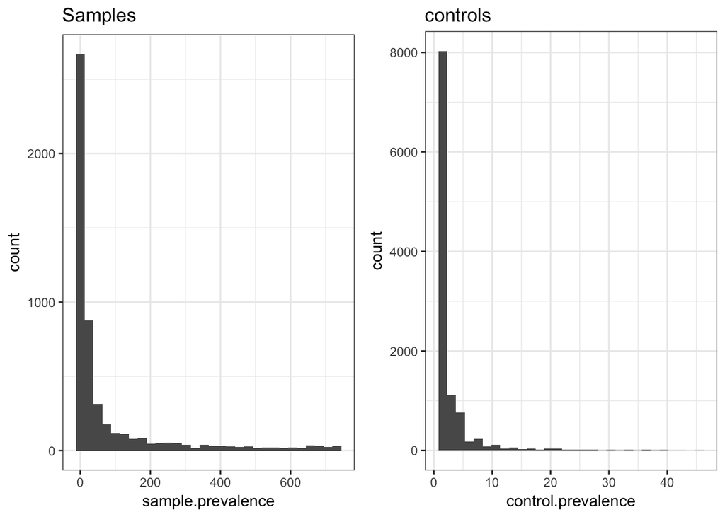

```r
p4=ggplot(cont.df, aes(sample.prevalence)) + geom_histogram() + ggtitle("Samples") + theme_bw()
p5=ggplot(cont.df, aes(control.prevalence)) + geom_histogram() + ggtitle("controls")+ theme_bw()
grid.arrange(p4, p5, ncol=2)
```

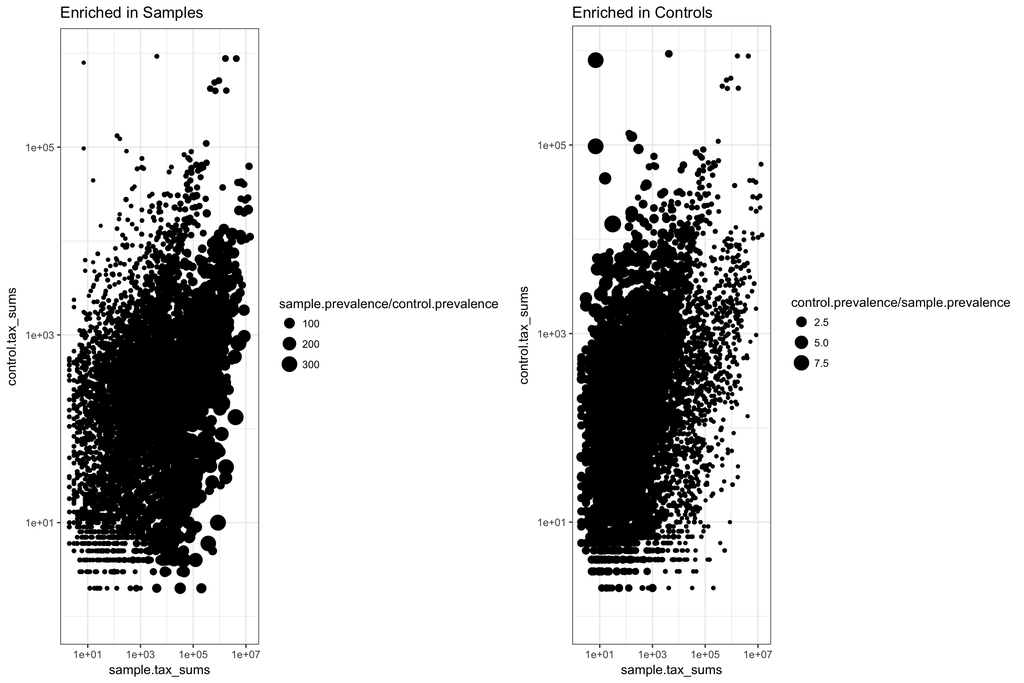

```r
p6 = ggplot(cont.df, aes(sample.tax_sums, control.tax_sums, size=sample.prevalence/control.prevalence)) + geom_point() + ggtitle("Enriched in Samples") + theme_bw() + scale_y_log10() + scale_x_log10()

p7 = ggplot(cont.df, aes(sample.tax_sums, control.tax_sums, size=control.prevalence/sample.prevalence)) + geom_point() + ggtitle("Enriched in Controls") + theme_bw() + scale_y_log10() + scale_x_log10()
grid.arrange(p6, p7, ncol=2)
```

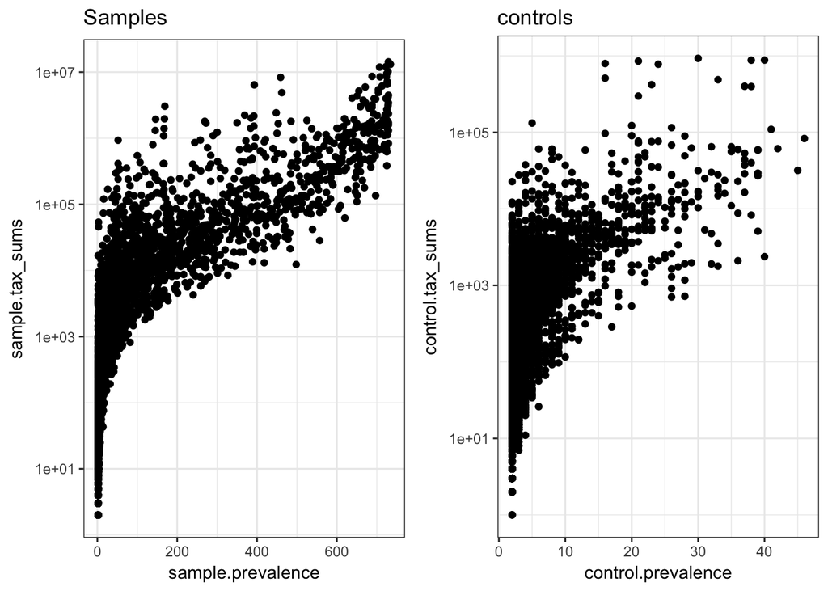

```r
p8=ggplot(cont.df, aes(sample.prevalence, sample.tax_sums)) + geom_point() + ggtitle("Samples") + theme_bw()+ scale_y_log10()
p9=ggplot(cont.df, aes(control.prevalence, control.tax_sums)) + geom_point() + ggtitle("controls")+ theme_bw()+ scale_y_log10()
grid.arrange(p8, p9, ncol=2)
```

### Generate the dataframe including summary of total sequencing depth per taxon, as well as taxon prevalence and rank - UNFILTERED DATA

```r
## Generate the dataframe including summary of total sequencing depth per taxon, as well as taxon prevalence and rank
library(reshape2); library(plyr);library(doBy)
#get rid of taxa in L0 from the dataset by subsetting on those in G0
names = taxa_names(G0)
Filtx = prune_taxa(names, unfiltered)

runs <- levels(sample_data(Filtx)$PoolName)
df.holder <-vector('list',length(runs))
for(i in 1:length(runs)){
        Filt1 = subset_samples(Filtx, PoolName==runs[[i]])
        #create  a technical dataset &  calculate technical taxa means
        technical <- subset_samples(Filt1, Aim =="Technical") #3985 taxa; 461 samples
        technical <- prune_taxa(taxa_sums(technical) > 0, technical)
        technical <- prune_samples(sample_sums(technical) > 0, technical)
        #create a sample dataest & center on technical taxa means
        samples <- subset_samples(Filt1, Aim != "Technical") #7953 taxa are present
        samples <- prune_taxa(taxa_sums(samples) > 0, samples)
        samples <- prune_samples(sample_sums(samples) > 0, samples)

#### Plot k (prevalence) over A (abundance)

tech <- data.frame(taxa_sums(technical), rownames(tax_table(technical)),tax_table(technical), t(otu_table(technical)))
        colnames(tech)[1:2] <- c("taxa_sums", "sequences")
        #rank order
        tech <- tech[order(tech$taxa_sums, decreasing=TRUE),]
        tech$rank <- 1:ntaxa(technical)
        tech.dfm <- melt(tech, id.var=c("sequences", "rank",
        colnames(tax_table(technical))))
        tech.dfm$binary <- ifelse(tech.dfm$value > 0, "1", "0")
        tech.dfm$binary <- as.numeric(as.character(tech.dfm$binary))

samp <- data.frame(taxa_sums(samples), rownames(tax_table(samples)), tax_table(samples), t(otu_table(samples)))
        colnames(samp)[1:2] <- c("taxa_sums", "sequences")
        #rank order
        samp <- samp[order(samp$taxa_sums, decreasing=TRUE),]
        samp$rank <- 1:ntaxa(samples)
        samp.dfm <- melt(samp, id.var=c("sequences", "rank",
        colnames(tax_table(samples))))
        samp.dfm$binary <- ifelse(samp.dfm$value > 0, "1", "0")
        samp.dfm$binary <- as.numeric(as.character(samp.dfm$binary))

#compute prevalence
tech.dfm2 <- summaryBy(binary~sequences, data=tech.dfm, id=c("rank", "Phylum", "value"), FUN=sum)
        dim(tech.dfm2) #should be equal to ntaxa(technical)
        tech.dfm2$prevalence <- 1+(100*(tech.dfm2$binary.sum/nsamples(technical)))
        rownames(tech.dfm2) <- tech.dfm2$sequences

samp.dfm2 <- summaryBy(binary~sequences, data=samp.dfm, id=c("rank", "Phylum", "value"), FUN=sum)
        dim(samp.dfm2) #should be equal to ntaxa(samples)
        samp.dfm2$prevalence <- 1+(100*(samp.dfm2$binary.sum/nsamples(samples)))
        rownames(samp.dfm2) <- samp.dfm2$sequences

#force the ordering of the two data frame to be the same
samp.dfm3 = samp.dfm2[rownames(tech.dfm2),]

df = data.frame(samp.dfm3$binary.sum, tech.dfm2$binary.sum, samp.dfm3$value, tech.dfm2$value, samp.dfm3$rank, tech.dfm2$rank,  samp.dfm3$Phylum, samp.dfm3$sequences)
df$PoolName <- runs[[i]]

colnames(df) <- c("sample.prevalence", "control.prevalence", "sample.tax_sums", "control.tax_sums","sample.rank", "control.rank", "Phylum", "Sequence")

df.holder[[i]] <- df
}

g0.df <- do.call("rbind", df.holder)
colnames(g0.df)[9] <- "run"

#subset on the taxa that are prevalent in samples but
good = subset(cont.df, sample.prevalence >0)

g0.df$subtracted <- g0.df$sample.tax_sums-g0.df$control.tax_sums
g0.df$number <- 1:nrow(g0.df)
p10=ggplot(g0.df, aes(sample.tax_sums)) + geom_histogram()+ scale_x_log10() + ggtitle("Samples")
p11=ggplot(g0.df, aes(control.tax_sums)) + geom_histogram()+ scale_x_log10() + ggtitle("controls")
p12 = ggplot(g0.df, aes(subtracted)) + geom_histogram()+ scale_x_log10() + ggtitle("subtracted")
```

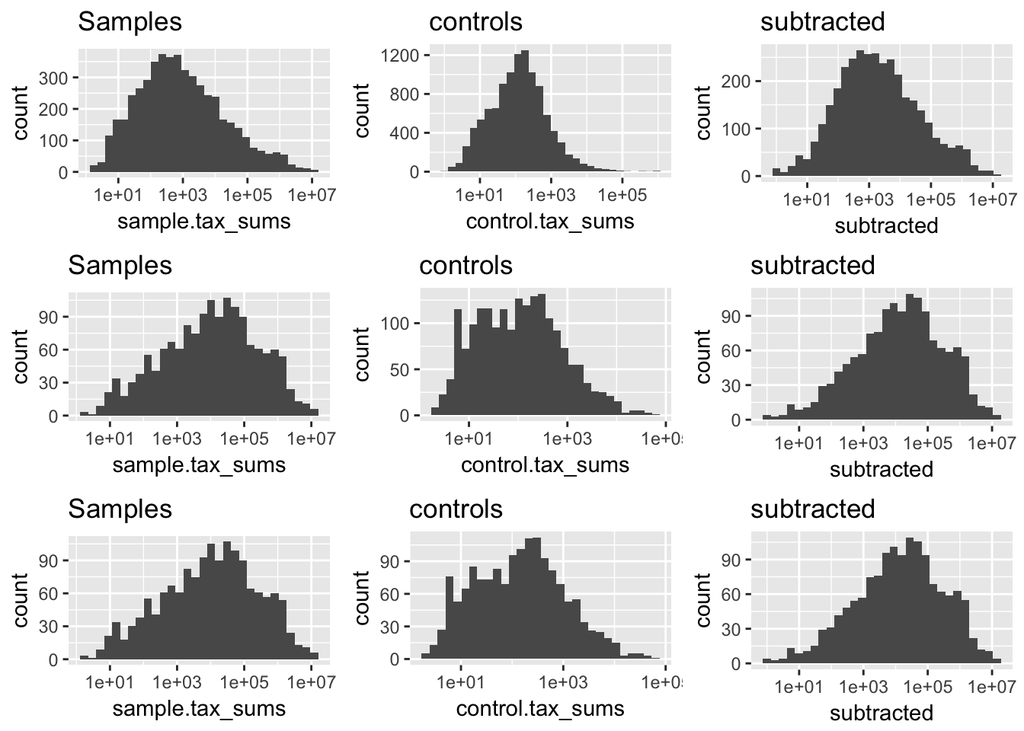

```r
good = subset(g0.df, sample.prevalence >0)
p13=ggplot(good, aes(sample.tax_sums)) + geom_histogram()+ scale_x_log10() + ggtitle("Samples")
p14=ggplot(good, aes(control.tax_sums)) + geom_histogram()+ scale_x_log10() + ggtitle("controls")
p15 = ggplot(good, aes(subtracted)) + geom_histogram()+ scale_x_log10() + ggtitle("subtracted")
grid.arrange(p1, p2, p3, p10, p11, p12, p13, p14, p15, ncol=3)
```

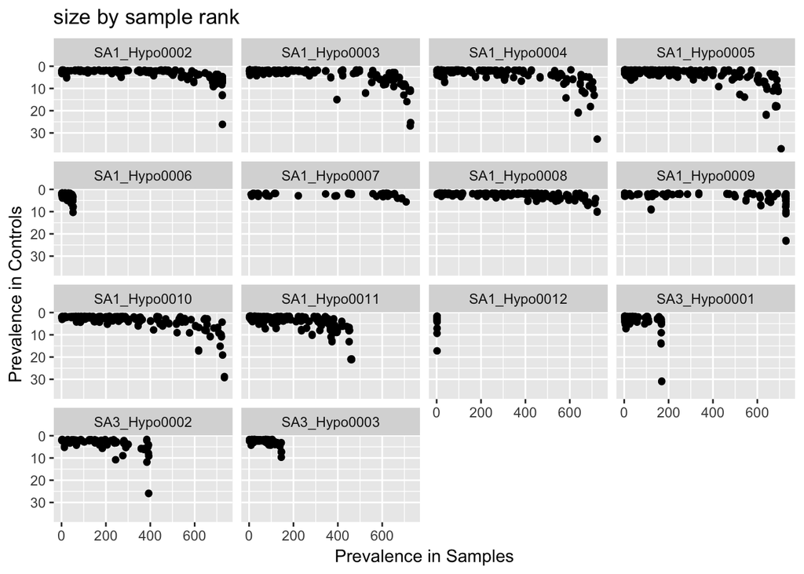

```r
ggplot(good, aes(sample.prevalence, control.prevalence)) + geom_jitter()  + ggtitle("prevalence") + geom_jitter() + ggtitle("size by sample rank") + scale_y_reverse() + ylab("Prevalence in Controls")  + xlab("Prevalence in Samples") + facet_wrap(~run)
```

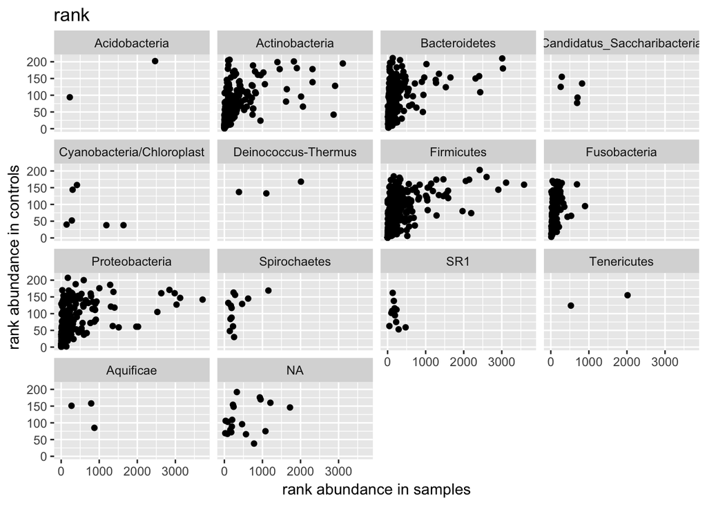

```r
ggplot(good, aes(sample.rank, control.rank))  + ggtitle("rank")   + geom_point()  + xlab("rank abundance in samples") + ylab("rank abundance in controls") + facet_wrap(~Phylum)
```

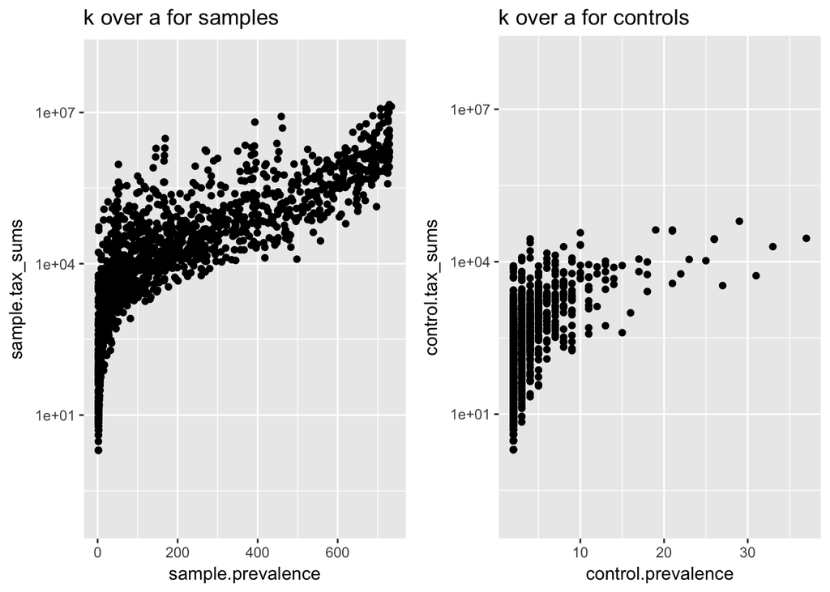

```r
p1 <- ggplot(good, aes(sample.prevalence, sample.tax_sums)) + geom_point()  + ggtitle("k over a for samples")+ scale_y_log10(limits = c(.1, 1e+08))

p2 <- ggplot(good, aes(control.prevalence, control.tax_sums)) + geom_point()  +  ggtitle("k over a for controls") + scale_y_log10(limits = c(.1, 1e+08))

grid.arrange(p1, p2, ncol=2)
```

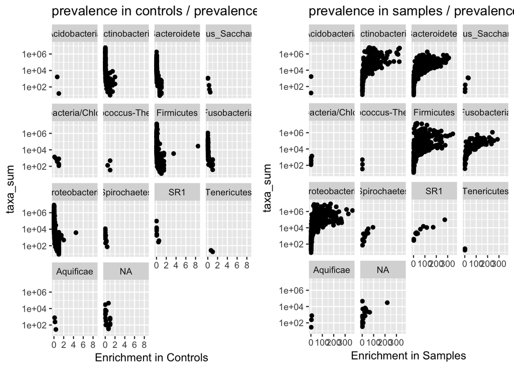

```r
df <- good
df$odds <- df$control.prevalence/df$sample.prevalence
df2 <- subset(df, df$control.prevalence & df$sample.prevalence !=0)
df2$odds.control <- df2$control.prevalence/df2$sample.prevalence
df2$odds.sample <- df2$sample.prevalence/df2$control.prevalence
df2$summarized <- df2$sample.tax_sums + df2$control.tax_sums

p1 <- ggplot(df2, aes(odds.control, summarized)) + geom_point() + scale_y_log10() + ggtitle("prevalence in controls / prevalence in samples") + facet_wrap(~Phylum) + xlab("Enrichment in Controls") + ylab("taxa_sum")
p2 <- ggplot(df2, aes(odds.sample, summarized)) + geom_point() + scale_y_log10() + ggtitle("prevalence in samples / prevalence in controls")+ facet_wrap(~Phylum) + xlab("Enrichment in Samples")+ ylab("taxa_sum")
grid.arrange(p1, p2, ncol=2)
```

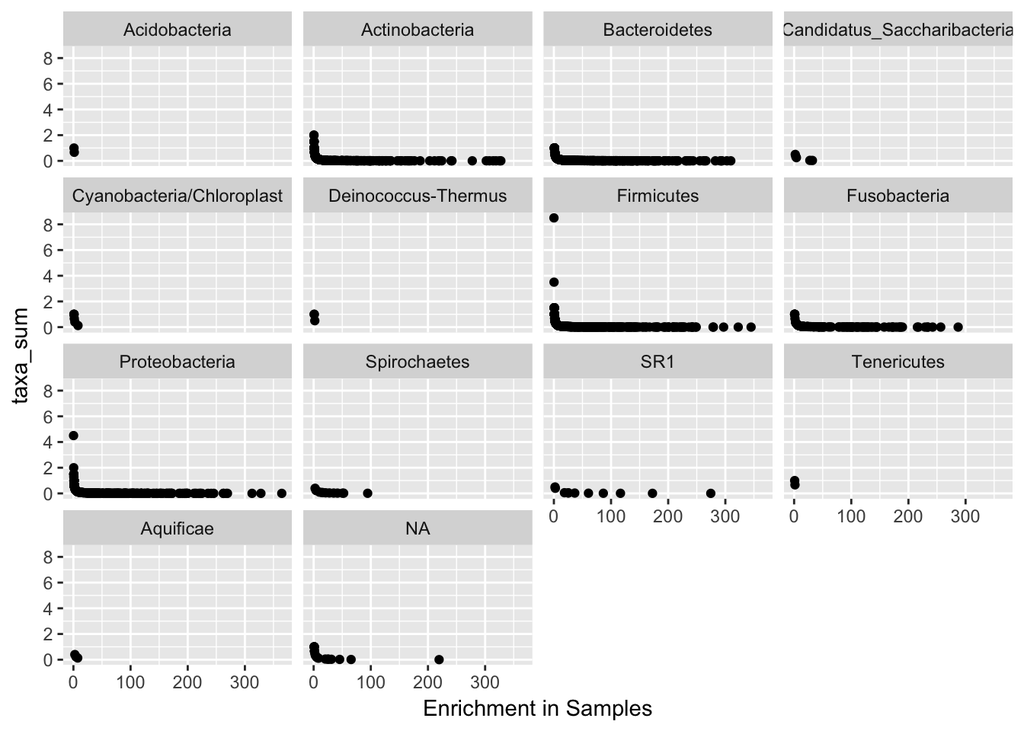

```r
ggplot(df2, aes(odds.sample, odds.control)) + geom_point() + facet_wrap(~Phylum) + xlab("Enrichment in Samples")+ ylab("taxa_sum")
```

```r
### Decontaminate the dataset by selecting taxa in "good"
names = as.vector(unique(df2$Sequence))
decontam.phy = prune_taxa(names, unfiltered)
        decontam.phy = prune_taxa(taxa_sums(decontam.phy) > 0, decontam.phy)
        decontam.phy = prune_samples(sample_sums(decontam.phy) >0, decontam.phy)
        decontam.phy # 1727 taxa and 7441 samples
```

```
## phyloseq-class experiment-level object
## otu_table()   OTU Table:         [ 480 taxa and 7412 samples ]
## sample_data() Sample Data:       [ 7412 samples by 30 sample variables ]
## tax_table()   Taxonomy Table:    [ 480 taxa by 6 taxonomic ranks ]
```

```r
library(dada2)
#sequence table from rdp classifier on rdp database
tax = tax_table(decontam.phy)
set.seed(100) # Initialize random number generator for reproducibility
taxa <- assignTaxonomy(rownames(tax), "~/Dropbox/Taxonomy/rdp_train_set_14.fa.gz", minBoot=80)
taxaSpecies <- addSpecies(taxa, "~/Dropbox/Taxonomy/rdp_species_assignment_14.fa.gz", verbose=TRUE)
```

```
## 152 out of 480 were assigned to the species level.
## Of which 139 had genera consistent with the input table.
```

```r
tax_table(decontam.phy) <- taxaSpecies
save.image("decontam15_v2.0.Rdata")


load("~/Dropbox/decontam15_v.0.Rdata") #this is from the decontamination script
map = read.csv("~/Dropbox/decontam_phy_quadrant_corrected.csv", row.names=1)
map = sample_data(map)
sample_data(decontam.phy) = map
saveRDS(decontam.phy, file="~/Dropbox/decontam.phy.rds")
```